# Lecture 9: How ggplot2 Graphs are Built and Modified

Nick Huntington-Klein

03 March, 2026

## Structuring ggplot

- Last time we went through the basics of the grammar of graphics
- And how to put together a ggplot graph:
- Data, aesthetics, geometry

## Today!

- We’ll talk about different ways of changing the *structure* of your ggplot
- Scales and coordinates, labels and legends, new geometries
- There are infinite possibilities here, we can’t cover everything
- The goal is to reduce unknown unknowns so you know where to look/Google

## Why?

- If we’re going to be using AI to edit and make our graphs look really good, why learn this?
- This will let you know what to ask for and how to be specific about asking
- And also will help you know how to validate the code you’re seeing and be sure you know what it’s doing
- Plus, these are the *kinds of structures* you’ll be looking for if you switch languages / graphing packages

## The Key Pieces

A common structure for a `ggplot()` command with a fair amount of customization might be:

```r
ggplot(data, aes(x = xvar, y = yvar, color = colorvar)) +
  geom_mygeometry(otheraesthetic = value) +
  scale_aesthetic_type(labels = something) +
  labs(x = 'My X Var', y = 'My Y Var', title = 'My Title') +
  guides(color = 'none')
```

## Scales

- Every axis (aesthetic element) has a *scale*
- This determines how *a value in the data* (1, 2, 3) turns into *a value on the graph* (100 pixels to the right, 200 pixels, 300 pixels; or “red”, “blue”, “green”)
- These scales are fully manipulable and label-able!
- `scale_axisname_type`

## Discrete and Continuous Scales

- For example:
- `scale_x_continuous` for a continuous x-axis
- `scale_x_discrete` for a discrete one
- Or similarly `scale_y_continuous`, `scale_color_continuous`, `scale_color_gradient`, `scale_fill_discrete`, and so on and so on

## Discrete and Continuous Scales

- Use to:
- Set colors, set limits (want the axis to extend beyond its values? `limits`)
- Name the scale
- Label values (for dicrete values, or perhaps as percents?)

## Examples

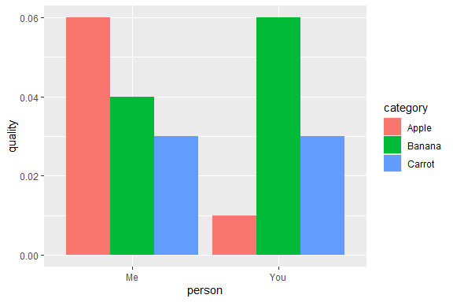

```r
data <- tibble(category = c('Apple','Banana','Carrot','Apple','Banana','Carrot'),
               person = c('Me','Me','Me','You','You','You'),
               quality = c(.06,.04,.03,.01,.06,.03))
ggplot(data, aes(x = person, y = quality, fill = category)) + geom_col(position = 'dodge')
```

## Setting Scales

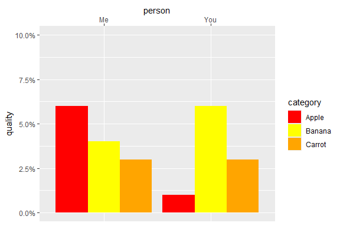

```r
library(scales)
ggplot(data, aes(x = person, y = quality, fill = category)) + geom_col(position = 'dodge') +
  scale_y_continuous(labels = label_percent(), limits = c(0,.1)) +
  scale_x_discrete(position = 'top') +
  scale_fill_manual(values = c('Apple'='red','Banana'='yellow','Carrot'='orange'))
```

## Setting Scales

- **Please customize your scales to the kind of data you’re showing**
- `labels` is handy. `labels = c('Red Apple',` `'Yellow Banana','Orange Carrot')` would relabel the legend (or axis labels)
- In a continuous function, say for dollars, `scale_x_continuous(labels = scales::label_dollar())` would put it in dollar terms. More on this in a moment
- Or setting date formats: `scale_x_date(date_labels = '%m/%Y')`

## Setting Color or Fill Scales

- Selecting a color scale is important - we’ve discussed discrete and continuous palettes
- There are a bunch of `scale_color_`/`scale_fill_` functions that solely exist to help with this!
- (not to mention entire packages like **paletteer**)
- You might browse the palettes yourself - AI isn’t great at picking palettes to match an intent yet

## Setting Color or Fill Scales

Especially useful are:

- `scale_color_gradient()` for gradient scales (or `_gradient2()` for diverging scales with a “middle” in them), `scale_color_viridis()` also has some great gradient scales (either discrete or continuous!)
- `scale_color_brewer()`/`scale_fill_brewer()` functions for discrete values, or `_distiller()` for continuous values, or `_fermenter()` for binned

## Setting Color or Fill Scales

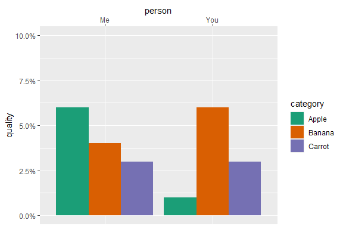

```r
ggplot(data, aes(x = person, y = quality, fill = category)) + geom_col(position = 'dodge') +
  scale_y_continuous(labels = label_percent(), limits = c(0,.1)) +
  scale_x_discrete(position = 'top') +
  scale_fill_brewer(palette = 'Dark2')
```

## Setting Color or Fill Scales

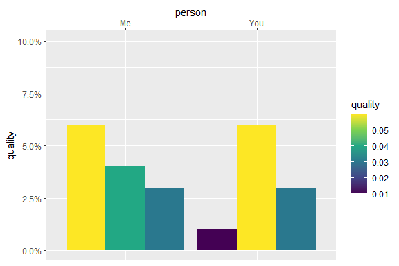

```r
ggplot(data, aes(x = person, y = quality, group = category, fill = quality)) + geom_col(position = 'dodge') +
  scale_y_continuous(labels = label_percent(), limits = c(0,.1)) +
  scale_x_discrete(position = 'top') +
  scale_fill_viridis_c()
```

## Setting Color or Fill Scales

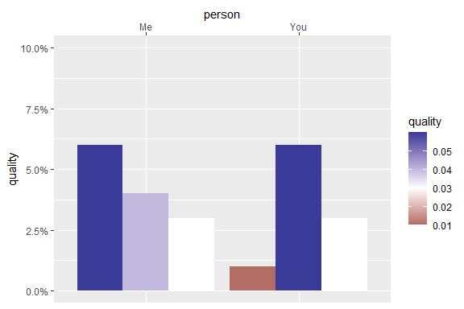

```r
ggplot(data, aes(x = person, y = quality, group = category, fill = quality)) + geom_col(position = 'dodge') +
  scale_y_continuous(labels = label_percent(), limits = c(0,.1)) +
  scale_x_discrete(position = 'top') +
  scale_fill_gradient2(midpoint = .03)
```

## Transformations

- We can transform values as we plot them
- Many `scale_something_continuous` entries have a `trans` option, set to `date`, `log`, `probability`, `reciprocal`, `sqrt`, `reverse`, etc. etc. to perform that transformation before plotting
- Some transformations have special `scale_` functions. TBH the only transformations I see frequently are `scale_something_log10()` or `scale_something_binned()`

## Transformations

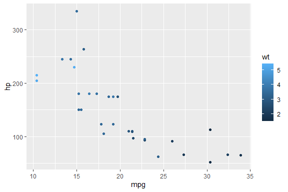

```r
ggplot(mtcars, aes(x = mpg, y = hp, color = wt)) +
  geom_point()
```

## Transformations

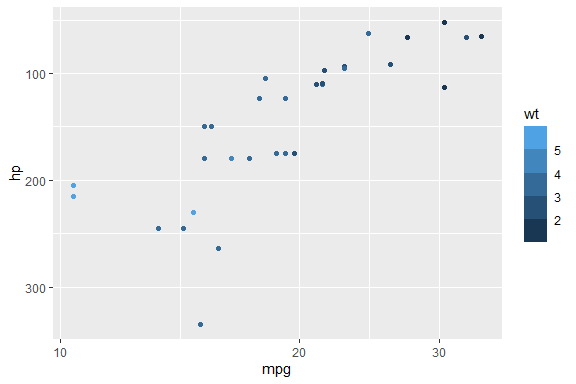

```r
ggplot(mtcars, aes(x = mpg, y = hp, color = wt)) +
  geom_point() +
  scale_x_log10() +
  scale_y_continuous(trans='reverse') +
  scale_color_binned()
```

## Log Scales

When to use log scales?

- When data is highly skewed, so a few huge observations are drawing all focus
- When the relationship is multiplicative so you want to show, say, percentage growth

## scales

Two main types of functions in **scales**:

- Transformation functions like `dollar()`: `dollar(10)` creates $10 (NOTE: handy sometimes in RMarkdown text! Also note this creates text, not numbers, so don’t use them in `aes()` unless you want the variable to be a string)
- Labeling functions like `label_dollar()` designed to slot directly into the `labels=` argument. `scale_y_continuous(labels = label_dollar())` turns all your y-axis labels into the dollar equivalent

## scales

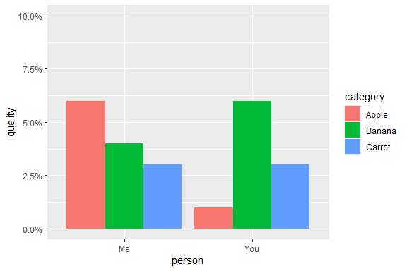

```r
ggplot(data, aes(x = person, y = quality, fill = category)) + geom_col(position = 'dodge') +
  scale_y_continuous(labels = label_percent(), limits = c(0,.1))
```

## Scales

The `label_` functions have lots of options! You can set the `accuracy` (precision), decide how to break up big numbers (`big.mark`) or scale things down to, say, thousands! (`scale=1/1000, suffix = 'k'`)

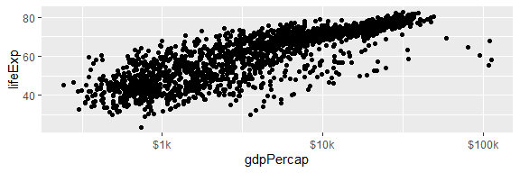

```r
data(gapminder, package = 'gapminder')
ggplot(gapminder, aes(x = gdpPercap, y = lifeExp)) + geom_point() +
  scale_x_log10(labels = label_dollar(accuracy = 1, scale = 1/1000, suffix = 'k'))
```

## Documentation

- There are a zillion options
- Be sure to use `help(whatever)` before using something
- For our purposes graphing with AI this will mostly be for the purposes of figuring out **what is possible** and if we can guide the AI to implement something in a specific way

## Labels with labs()

- Please label your axes and graphs!!
- Label legends too by naming their axes
- Captions and subcaptions available too
- Annotation and labeling data points we’ll do next time

## All Kinds of Labels

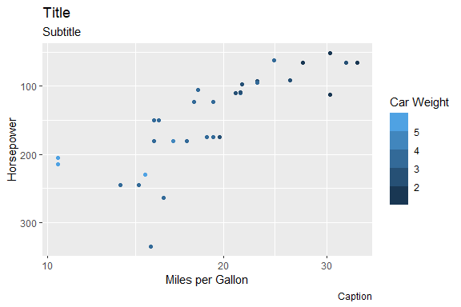

```r
data(mtcars)
mtcars <- mtcars %>% mutate(CarName = row.names(mtcars))
ggplot(mtcars, aes(x = mpg, y = hp, color = wt)) + geom_point() +
  scale_x_log10() + scale_y_reverse() + scale_color_binned() +
  labs(x = 'Miles per Gallon', y = 'Horsepower', color = 'Car Weight',
       title = 'Title', subtitle = 'Subtitle', caption = 'Caption')
```

## Overlaid Graphs

- In addition to adding chart elements, we can add whole new geometries over the top
- Some stack naturally (adding a `geom_smooth` best fit line over top, for example)
- For others we may have to change the data or aesthetic as we go

## Overlaid Graphs

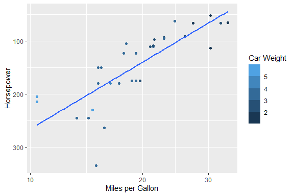

```r
ggplot(mtcars, aes(x = mpg, y = hp, color = wt)) + geom_point() +
  scale_x_log10() + scale_y_reverse() + scale_color_binned() +
  labs(x = 'Miles per Gallon', y = 'Horsepower', color = 'Car Weight') +
  geom_smooth(method='lm', se = FALSE)
```

## Overlaid Graphs

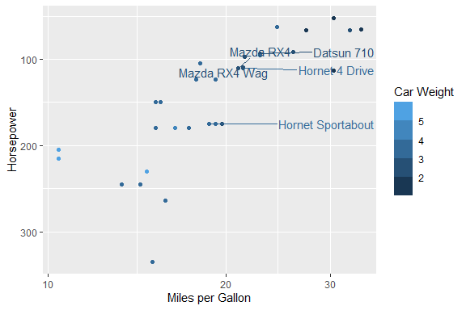

```r
ggplot(mtcars, aes(x = mpg, y = hp, color = wt)) + geom_point() +
  scale_x_log10() + scale_y_reverse() + scale_color_binned() +
  labs(x = 'Miles per Gallon', y = 'Horsepower', color = 'Car Weight') +
  geom_text_repel(data = mtcars %>% slice(1:5),aes(label = CarName),hjust=-1)
```

## Facets

- Separate graphs by group!
- For sticking together multiple completely disparate graphs, don’t use facets, instead load **patchwork** and combine them as desired - we’ll discuss this later

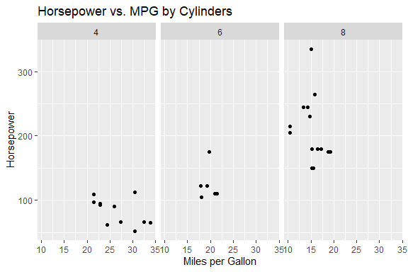

```r
ggplot(mtcars, aes(x = mpg, y = hp)) + geom_point() +
  facet_wrap('cyl') +
  labs(x = 'Miles per Gallon', y = 'Horsepower', title = 'Horsepower vs. MPG by Cylinders')
```

## ggforce’s facet_zoom

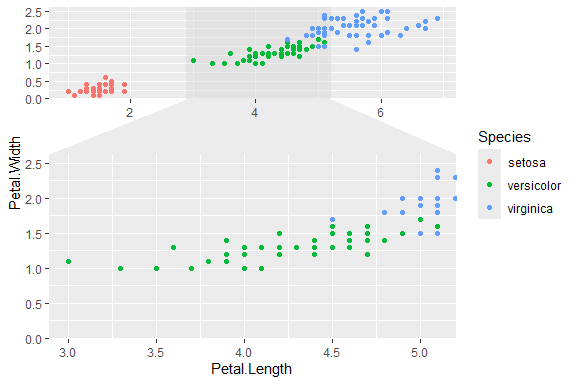

```r
library(ggforce)
ggplot(iris, aes(Petal.Length, Petal.Width, colour = Species)) +
  geom_point() +
  facet_zoom(x = Species == 'versicolor')
```

## Imitation and Flattery

- Pick one of these graphs or from the previous lecture
- Go into the geometry’s help file and recreate an example, or the graph in these slides
- Mess with the scales and labels! Try to get it to work!

## Make it Look Good

- Let’s talk about how to set aesthetic attributes along every axis
- As well as overall styling and theming
- Highlighting, putting graphs together, making them interactive, annotating…
- **Think about this stuff**. Your graphs will look unprofessional if you don’t, and I’ll start grading down all-default styling or missed opportunities for improvement.

## Aesthetic Characteristics

- As you’d expect, we’ll be setting the values of certain aesthetic properties
- Which ones apply depend on the geometry. See [this page](https://ggplot2.tidyverse.org/articles/ggplot2-specs.html). Some common ones:
- color, linetype, fill, size, shape (and soon: linewidth)
- Text aesthetics: family (font), fontface, hjust, vjust (see **extrafont** package to use all your system fonts)

## Decorating Axes vs. Decorating Geometries

- When a characteristic is set *inside* of an `aes()`, it becomes an axis and must be mapped to a variable name
- *Outside* of an `aes()` (and in the geometry), it’s a setting applied to the entire geometry

## Aesthetic Characteristics

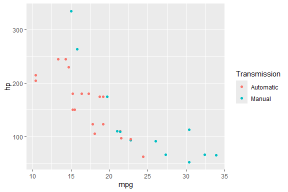

```r
# We've seen this before
mtcars <- mtcars %>%
  mutate(Transmission = factor(am, labels = c('Automatic','Manual')))
ggplot(mtcars, aes(x = mpg, y = hp, color = Transmission)) +
  geom_point()
```

## Aesthetic Characteristics

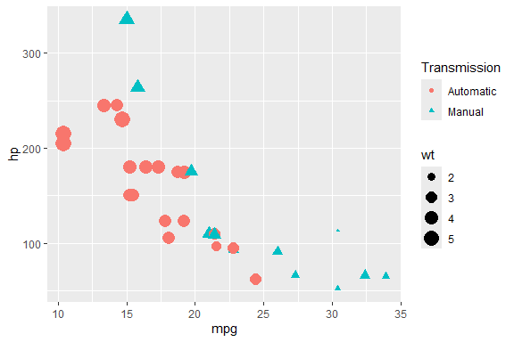

```r
ggplot(mtcars, aes(x = mpg, y = hp, color = Transmission,
                   size = wt, shape = Transmission)) +
  geom_point()
```

## Aesthetic Characteristics

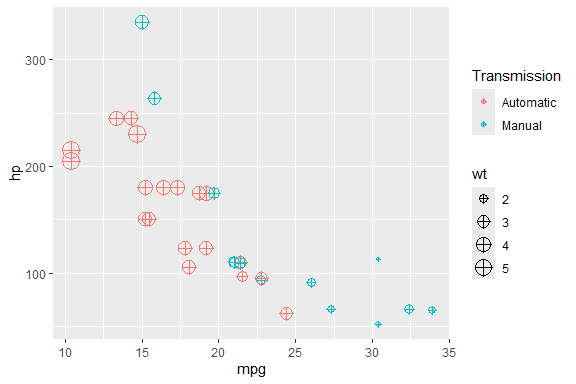

```r
ggplot(mtcars, aes(x = mpg, y = hp, color = Transmission,
                   size = wt)) +
  geom_point(shape = 10)
```

## Aesthetic Characteristics

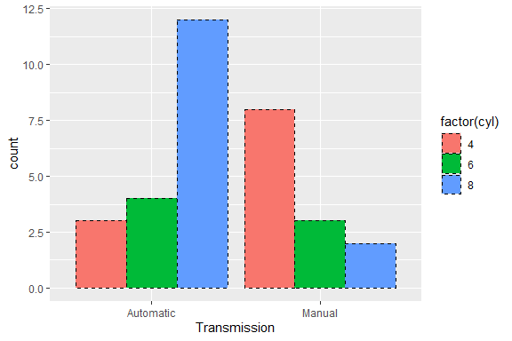

```r
ggplot(mtcars, aes(x = Transmission, fill = factor(cyl))) +
  geom_bar(position = 'dodge', linetype = 'dashed', color = 'black')
```

## Theming

- Pretty much all elements of presentation that aren’t in a geometry can be controlled with `theme()`
- The options are endless! See `help(theme)`
- We set different aspects of the theme using `element_` functions like `element_text()`, `element_line()`, `element_rect()` which take aesthetic settings like `size`, `color`, etc.
- This stuff can be used on its own or in conjunction with prepackaged themese like `theme_classic()` or `theme_minimal()` or `theme_void()`

## Axes

- Change axis and tick lines with `axis.line` and `element_line`
- Most everything can be changed generally (`axis.line` or even `line`) or specifically (`axis.ticks.x`)

```r
library(ggalt)
mtcars2 <- mtcars %>% group_by(Transmission) %>% summarize(count = n())
ggplot(mtcars2, aes(x = Transmission,y=count)) +
  geom_lollipop(color = 'red', size = 2) + coord_flip() +
  labs(x = '', y = '') +
  scale_y_continuous(breaks = c(10,20), limits = c(0,20)) +
  theme(axis.line = element_line(color = 'red'),
        axis.ticks.x = element_line(size = 5))
```

## Axes

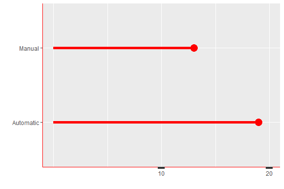

## Background

- Work on the `panel` to change what goes behind that geometry! `element_rect` might come up!
- Pretty much ANY element can be eliminated with `element_blank()`
- This gonna be ugly

```r
ggplot(mtcars2, aes(x = Transmission,y=count)) +
  geom_lollipop(color = 'red', size = 2) + coord_flip() +
  theme(panel.background = element_rect(color = 'blue', fill = 'yellow'),
        panel.grid.major.x = element_line(color = 'green'),
        panel.grid.major.y = element_blank())
```

## Background

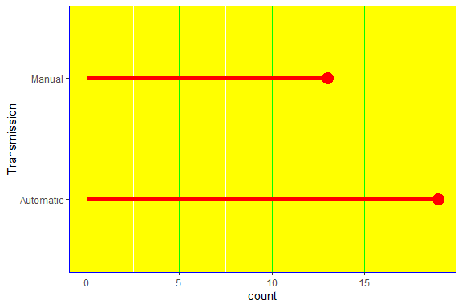

## Legends

- Think carefully about your legend!
- We’ll leave the legend coding to AI - it’s unnecessarily complicated. But ask yourself questions like:
- Do I need a legend?
- Where should the legend be placed?
- How can I make the legend easy to read?

## General Theming Notes

- How can we think about theming generally?
- We want, as always, to drive focus towards our story
- This means not making the theme distracting it, but using it to drive attention to what we want
- Need focus on the x-axis labels? Make em bold!
- Often we don’t need distracting background color (as there is in the default theme). Usually get rid of it!

## Other Styling

- Let’s move on to some other ways we can build focus and clarity
- Highlight and annotations!

## Highlighting

- Highlight certain values and gray others with the **gghighlight** package

```r
library(gghighlight); data(gapminder, package = 'gapminder')
ggplot(gapminder, aes(x = year, y = lifeExp, color=country)) + geom_line(size = 1.5) +
  labs(x = NULL, y = "Life Expectancy", title = "North America Only") +
  scale_x_continuous(limits=c(1950,2015),
                     breaks = c(1950,1970,1990,2010))+
  gghighlight(country %in% c('United States','Canada','Mexico'),
              unhighlighted_params = aes(size=.1),
              label_params=list(direction='y',nudge_x=10)) +
  theme_minimal(base_family='serif')
```

## Highlighting

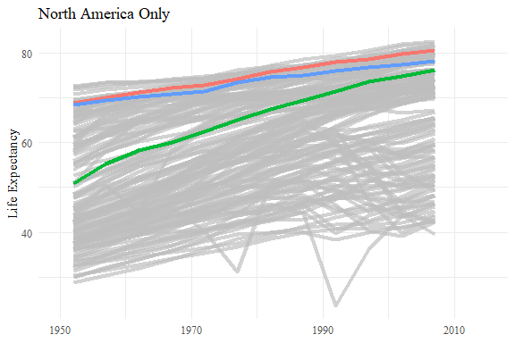

## Highlighting

- Or do it manually with `scale_X_manual()`

```r
gapminder %>% mutate(color_name = ifelse(country %in% c('United States','Canada','Mexico'), as.character(country), 'Other')) %>%
ggplot(aes(x = year, y = lifeExp, group = country, color=color_name, size = color_name, alpha = color_name)) + geom_line() +
  geom_text(aes(label = ifelse(year == 2007 & color_name != 'Other', color_name,'')),
                           hjust = 0, size = 13/.pt) +
  labs(x = NULL, y = "Life Expectancy", title = "North America Only") +
  scale_x_continuous(limits=c(1950,2025),
                     breaks = c(1950,1970,1990,2010))+
  scale_color_manual(values = c('red','forestgreen','gray','blue')) +
  scale_size_manual(values = c(1.5,1.5,.1,1.5)) +
  scale_alpha_manual(values = c(1,1,.2,1)) +
  theme_minimal(base_family='serif') +
  guides(color = 'none', size = 'none', alpha = 'none')
```

## Highlighting

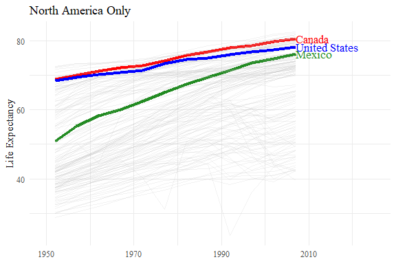

## Annotation

- There are also many options for *annotating* our data
- For direct data point annotation, especially of line graphs, you can do this with some data manipulation and `geom_text` (see previous slide)
- AI should be able to put labels and arrows one by one on your graph; you may have to twiddle on your own with coordinates to make it line up properly

## Patchwork

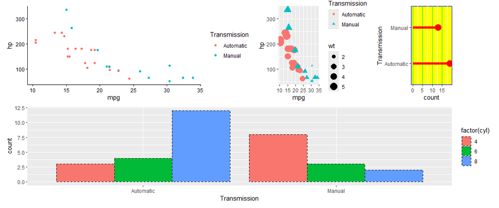

```r
library(patchwork)
# Named and saved these earlier
(p1 | p2 - p3)/p4
```

## What Did We Learn?

- Scales, setting labels, values, and transformations
- Axis labels
- Facets
- Theming
- Thinking about legends
- Annotation and highlighting (do it!)